# An Investigation into the Houston Astros Cheating Scandal

By Chandler Hayden, Fall 2019

## Introduction

In November of 2019, the Houston Astros were accused of cheating during the 2017, 2018, and 2019 Major League Baseball seasons. Former Astros players admitted that the team cheated, and an email from a Houston executive was leaked which urged their scouts to spy on other teams. They are accused of using cameras and other technology during home games to steal the catcher's signs and then relay the information to their batters so that they would have an advantage by knowing what pitch was coming next. The Astros won the World Series in 2017 and again made it to the World Series in 2019. We will focus our investigation on the 2017 season when they won the World Series after not even making the playoffs the previous year.

Using statistics from the past three seasons and further historical data, we will investigate to see if there are any anomalies that may suggest that the Houston Astros had an unfair advantage working in their favor.

For more information: https://www.cbssports.com/mlb/news/astros-sign-stealing-scandal-what-to-know-about-cheating-allegations-and-mlbs-investigation/

## Required Libraries

1. lxml - for processing HTML
2. requests - for HTTP GET requests
3. BeautifulSoup - for web scraping
4. pandas - a toolkit which allows us to create and work with DataFrames
5. numpy - a package for scientific computing
6. matplotlib.pyplot - for graphing
7. statsmodels.api - a module for the estimation of statistical models
8. sklearn - for regressions and modeling  
   For more information on python and pandas:  
   https://docs.python.org/3/  
   https://pandas.pydata.org/pandas-docs/stable/install.html

```python
pip install lxml
```

```
     |████████████████████████████████| 5.8MB 3.3MB/s eta 0:00:01
```

```python
import requests
from bs4 import BeautifulSoup
import pandas as pd
import numpy as np
import matplotlib.pyplot as plt
import statsmodels.api as sm
from sklearn import linear_model, model_selection
from sklearn.linear_model import LinearRegression
```

## 1. Data Curation

We will be using statistics from www.baseball-reference.com. We scrape the data using GET requests and then use BeautifulSoup to look through the HTML to find the tables that we want to use. We then convert the data into pandas DataFrames.

```python
# Creating a DataFrame containing historical team win totals.
r=requests.get('https://www.baseball-reference.com/leagues/MLB/index.shtml')
root = BeautifulSoup(r.content)
table = root.find("table")
data = pd.read_html(str(table))
wintotals = data[0]
# Creating a DataFrame containing the Astros 2019 home vs. away splits.
r=requests.get('https://www.baseball-reference.com/teams/HOU/2019-schedule-scores.shtml')
root = BeautifulSoup(r.content)
table = root.find("table")
data = pd.read_html(str(table))
splits = data[0]
# Creating a DataFrame containing team batting ratios from the 2017 season.
r=requests.get('https://www.baseball-reference.com/leagues/MLB/2017-ratio-batting.shtml')
root = BeautifulSoup(r.content)
table = root.find("table")
data = pd.read_html(str(table))
ratios2017 = data[0]
# Creating a DataFrame containing team batting ratios from the 2016 season.
r=requests.get('https://www.baseball-reference.com/leagues/MLB/2016-ratio-batting.shtml')
root = BeautifulSoup(r.content)
table = root.find("table")
data = pd.read_html(str(table))
ratios2016 = data[0]
# Creating a DataFrame containing pitches batting information from the 2017 season.
r=requests.get('https://www.baseball-reference.com/leagues/MLB/2017-pitches-batting.shtml')
root = BeautifulSoup(r.content)
table = root.find("table")
data = pd.read_html(str(table))
pitches2017 = data[0]
```

## 2. Data Parsing and Management

The DataFrames that we just created have repeated rows at the bottom so we will remove those. We'll also remove some columns that we aren't going to look at so the rest of the data is easier to see. Also, a lot of the data points we now have are numbers represented as strings. To make our data analysis easier, we will convert the strings to floats.

```python
# Dropping rows
ratios2017 = ratios2017.drop([31, 32], axis=0)
ratios2016 = ratios2016.drop([31, 32], axis=0)
pitches2017 = pitches2017.drop([31, 32], axis=0)
# Dropping columns
pitches2017 = pitches2017.drop(pitches2017.columns[[1,2,3,4,5]], axis=1)
# Converting strings to floats
ratios2017['AB/SO'] = ratios2017['AB/SO'].astype(float)
ratios2016['AB/SO'] = ratios2016['AB/SO'].astype(float)
```

For the DataFrame holding the historical win totals, we will remove all of the rows prior to 1998. 1998 is the first year where the current 30 MLB teams were in the league. We'll also drop a column that is a duplicate of another team with empty cells. We'll keep a Series containing the years and then drop that column so that all the cells hold the number of wins.

```python
wintotals = wintotals.drop(wintotals.index[22:123], axis=0)
year_list = wintotals['Year']
wintotals = wintotals.drop(wintotals.columns[[0, 1, 4]], axis=1)
```

## 3. Data Analysis

### 3.1

The following table is the total wins for each team from 1998 to 2019.

```python
display(wintotals)
```

|  | ARI | ATL | BAL | BOS | CHC | CHW | CIN | CLE | COL | DET | ... | PHI | PIT | SDP | SFG | SEA | STL | TBR | TEX | TOR | WSN |
| --- | --- | --- | --- | --- | --- | --- | --- | --- | --- | --- | --- | --- | --- | --- | --- | --- | --- | --- | --- | --- | --- |
| 0 | 85 | 97 | 54 | 84 | 84 | 72 | 75 | 93 | 71 | 47 | ... | 81 | 69 | 70 | 77 | 68 | 91 | 96 | 78 | 67 | 93 |
| 1 | 82 | 90 | 47 | 108 | 95 | 62 | 67 | 91 | 91 | 64 | ... | 80 | 82 | 66 | 73 | 89 | 88 | 90 | 67 | 73 | 82 |
| 2 | 93 | 72 | 75 | 93 | 92 | 67 | 68 | 102 | 87 | 64 | ... | 66 | 75 | 71 | 64 | 78 | 83 | 80 | 78 | 76 | 97 |
| 3 | 69 | 68 | 89 | 93 | 103 | 78 | 68 | 94 | 75 | 86 | ... | 71 | 78 | 68 | 87 | 86 | 86 | 68 | 95 | 89 | 95 |
| 4 | 79 | 67 | 81 | 78 | 97 | 76 | 64 | 81 | 68 | 74 | ... | 63 | 98 | 74 | 84 | 76 | 100 | 80 | 88 | 93 | 83 |
| 5 | 64 | 79 | 96 | 71 | 73 | 73 | 76 | 85 | 66 | 90 | ... | 73 | 88 | 77 | 88 | 87 | 90 | 77 | 67 | 83 | 96 |
| 6 | 81 | 96 | 85 | 97 | 66 | 63 | 90 | 92 | 74 | 93 | ... | 73 | 94 | 76 | 76 | 71 | 97 | 92 | 91 | 74 | 86 |
| 7 | 81 | 94 | 93 | 69 | 61 | 85 | 97 | 68 | 64 | 88 | ... | 81 | 79 | 76 | 94 | 75 | 88 | 90 | 93 | 73 | 98 |
| 8 | 94 | 89 | 69 | 90 | 71 | 79 | 79 | 80 | 73 | 95 | ... | 102 | 72 | 71 | 86 | 67 | 90 | 91 | 96 | 81 | 80 |
| 9 | 65 | 91 | 66 | 89 | 75 | 88 | 91 | 69 | 83 | 81 | ... | 97 | 57 | 90 | 92 | 61 | 86 | 96 | 90 | 85 | 69 |
| 10 | 70 | 86 | 64 | 95 | 83 | 79 | 78 | 65 | 92 | 86 | ... | 93 | 62 | 75 | 88 | 85 | 91 | 84 | 87 | 75 | 59 |
| 11 | 82 | 72 | 68 | 95 | 97 | 89 | 74 | 81 | 74 | 74 | ... | 92 | 67 | 63 | 72 | 61 | 86 | 97 | 79 | 86 | 59 |
| 12 | 90 | 84 | 69 | 96 | 85 | 72 | 72 | 96 | 90 | 88 | ... | 89 | 68 | 89 | 71 | 88 | 78 | 66 | 75 | 83 | 73 |
| 13 | 76 | 79 | 70 | 86 | 66 | 90 | 80 | 78 | 76 | 95 | ... | 85 | 67 | 88 | 76 | 78 | 83 | 61 | 80 | 87 | 71 |
| 14 | 77 | 90 | 74 | 95 | 79 | 99 | 73 | 93 | 67 | 71 | ... | 88 | 67 | 82 | 75 | 69 | 100 | 67 | 79 | 80 | 81 |
| 15 | 51 | 96 | 78 | 98 | 89 | 83 | 76 | 80 | 68 | 72 | ... | 86 | 72 | 87 | 91 | 63 | 105 | 70 | 89 | 67 | 67 |
| 16 | 84 | 101 | 71 | 95 | 88 | 86 | 69 | 68 | 74 | 43 | ... | 86 | 75 | 64 | 100 | 93 | 85 | 63 | 71 | 86 | 83 |
| 17 | 98 | 101 | 67 | 93 | 67 | 81 | 78 | 74 | 73 | 55 | ... | 80 | 72 | 66 | 95 | 93 | 97 | 55 | 72 | 78 | 83 |
| 18 | 92 | 88 | 63 | 82 | 88 | 83 | 66 | 91 | 73 | 66 | ... | 86 | 62 | 79 | 90 | 116 | 93 | 62 | 73 | 80 | 68 |
| 19 | 85 | 95 | 74 | 85 | 65 | 95 | 85 | 90 | 82 | 79 | ... | 65 | 69 | 76 | 97 | 91 | 95 | 69 | 71 | 83 | 67 |
| 20 | 100 | 103 | 78 | 94 | 67 | 75 | 96 | 97 | 72 | 69 | ... | 77 | 78 | 74 | 86 | 79 | 75 | 69 | 95 | 84 | 68 |
| 21 | 65 | 106 | 79 | 92 | 90 | 80 | 77 | 89 | 77 | 65 | ... | 75 | 69 | 98 | 89 | 76 | 83 | 63 | 88 | 88 | 65 |

22 rows × 30 columns

Here we'll make a line chart with the year on the x-axis and the wins on the y-axis. Each team will have a line.

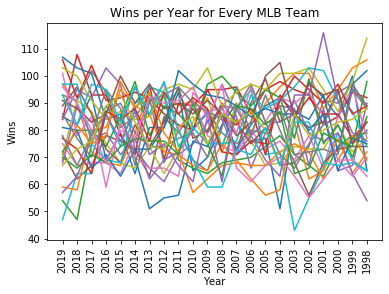

```python
columns = list(wintotals)
for i in columns:
    win_list = wintotals[i].astype(float)
    plt.plot(year_list, win_list)
    plt.ylabel('Wins')
    plt.xlabel('Year')
    plt.xticks(rotation=90)
    plt.title('Wins per Year for Every MLB Team')
```

There's a lot of lines here making this chart hard to interpret, but we'll come back to this data later. In the mean time, to be able to interpret this better I'll make a line chart showing just the Astros win totals compared to the league average.

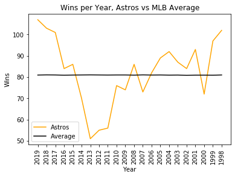

```python
astros_wins = wintotals['HOU'].astype(float)
for i in columns:
    wintotals[i] = wintotals[i].astype(int)
average_wins = wintotals.mean(axis=1)
plt.plot(year_list, astros_wins, color='orange', label='Astros')
plt.plot(year_list, average_wins, color='black', label='Average')
plt.ylabel('Wins')
plt.xlabel('Year')
plt.xticks(rotation=90)
plt.title('Wins per Year, Astros vs MLB Average')
plt.legend()
plt.show()
```

After creating this plot, we see that plotting the league average isn't helpful because it consistently stays the same. This makes sense because in every game, one team wins and the other loses so they offset eachother. This plot is still useful though to see the Astros win totals. Specifically, the increase they experienced between 2016 and 2019. In 2016 they won 84 games, 101 in 2017 (a 17 win increase!), 103 in 2018, and 107 in 2019. While one might think this large increase is the result of cheating, we can see that they had experienced quick improvement in previous years as well. Next, we'll take a look at how the Astros did specifically in 2019.

### 3.2

The following table is a record of every single Astros game played in 2019.

```python
splits.head()
```

|  | Gm# | Date | Unnamed: 2 | Tm | Unnamed: 4 | Opp | W/L | R | RA | Inn | ... | Rank | GB | Win | Loss | Save | Time | D/N | Attendance | Streak | Orig. Scheduled |
| --- | --- | --- | --- | --- | --- | --- | --- | --- | --- | --- | --- | --- | --- | --- | --- | --- | --- | --- | --- | --- | --- |
| 0 | 1 | Thursday, Mar 28 | boxscore | HOU | @ | TBR | W | 5 | 1 | NaN | ... | 2 | 1.0 | Verlander | Snell | NaN | 2:38 | D | 25025 | + | NaN |
| 1 | 2 | Friday, Mar 29 | boxscore | HOU | @ | TBR | L | 2 | 4 | NaN | ... | 2 | 1.0 | Morton | Cole | Alvarado | 2:38 | N | 13059 | - | NaN |
| 2 | 3 | Saturday, Mar 30 | boxscore | HOU | @ | TBR | L | 1 | 3 | NaN | ... | 3 | 2.0 | Glasnow | McHugh | Alvarado | 2:40 | N | 16010 | -- | NaN |
| 3 | 4 | Sunday, Mar 31 | boxscore | HOU | @ | TBR | L | 1 | 3 | NaN | ... | 4 | 3.0 | Chirinos | Miley | Castillo | 2:12 | D | 18473 | --- | NaN |
| 4 | Gm# | April | NaN | Tm | NaN | Opp | W/L | R | RA | Inn | ... | Rank | GB | Win | Loss | Save | Time | D/N | Attendance | Streak | Orig. Scheduled |

5 rows × 21 columns

Since it would have been easier to cheat in their home stadium where they could have already had cameras setup, I'm going to look into how they did at home versus away games. I'm going to need to clean up this data and create a new DataFrame with only the information that I need.

```python
home_games = 0
home_wins = 0
road_games = 0
road_wins = 0
#Iterate through the DataFrame and count the number of home wins and road wins.
for index, row in splits.iterrows():
    if(row[3] != 'Tm'):
        if(row[4] == '@'):
            road_games = road_games + 1
            if(row['W/L'] == 'W'):
                road_wins = road_wins + 1
        else:
            home_games = home_games + 1
            if(row['W/L'] == 'W' or row['W/L'] == 'W-wo'):
                home_wins = home_wins + 1

#Calculate the win percentage at home and away.
home_win_pct = home_wins / home_games
road_win_pct = road_wins / road_games

#Create DataFrame
splits_data = [[home_games, home_wins, home_win_pct, road_games, road_wins, road_win_pct]]
columns = ['Home Games', 'Home Wins', 'Home Win %', 'Road Games', 'Road Wins', 'Road Win %']
splits_df = pd.DataFrame(splits_data, columns = columns)
display(splits_df)
```

|  | Home Games | Home Wins | Home Win % | Road Games | Road Wins | Road Win % |
| --- | --- | --- | --- | --- | --- | --- |
| 0 | 81 | 60 | 0.740741 | 81 | 47 | 0.580247 |

After cleaning up that giant DataFrame, we can now see clearly how the Astros did in home games and away games. They play exactly half of their games at home and half away, or 81 games each. In 2019, they won 60 games at home, and only 47 on the road. If you look at the win percentages, at home they won 74% of games. On the road, they only won 58% of games, considerably less than at home. Teams are usually considered to have a "home field advantage", but this difference seems a bit extreme. Next, we'll take a look at some batting specific stats.

### 3.3

The following table is of team batting ratios from the 2017 season.

```python
display(ratios2017)
```

|  | Tm | R/G | HR% | SO% | BB% | XBH% | X/H% | SO/W | AB/SO | AB/HR | AB/RBI | GB/FB | GO/AO | IP% | LD% | HR/FB | IF/FB |
| --- | --- | --- | --- | --- | --- | --- | --- | --- | --- | --- | --- | --- | --- | --- | --- | --- | --- |
| 0 | ARI | 5.01 | 3.5% | 23.4% | 9.3% | 9.2% | 41% | 2.52 | 3.8 | 25.1 | 7.1 | 0.84 | 1.15 | 62% | 26% | 11.1% | 11% |
| 1 | ATL | 4.52 | 2.7% | 19.1% | 7.6% | 7.7% | 33% | 2.50 | 4.7 | 33.8 | 7.9 | 0.90 | 1.31 | 69% | 25% | 7.8% | 9% |
| 2 | BAL | 4.59 | 3.8% | 23.0% | 6.4% | 8.4% | 35% | 3.60 | 4.0 | 24.4 | 7.9 | 0.79 | 1.05 | 66% | 26% | 11.2% | 12% |
| 3 | BOS | 4.85 | 2.7% | 19.3% | 9.0% | 7.7% | 34% | 2.14 | 4.6 | 33.7 | 7.7 | 0.84 | 1.09 | 68% | 25% | 8.0% | 13% |
| 4 | CHC | 5.07 | 3.6% | 22.3% | 9.9% | 8.4% | 38% | 2.25 | 3.9 | 24.6 | 7.0 | 0.84 | 1.23 | 62% | 25% | 11.3% | 11% |
| 5 | CHW | 4.36 | 3.1% | 23.1% | 6.6% | 7.9% | 34% | 3.48 | 3.9 | 29.6 | 8.2 | 0.91 | 1.18 | 65% | 24% | 9.8% | 12% |
| 6 | CIN | 4.65 | 3.5% | 21.4% | 9.1% | 8.1% | 36% | 2.35 | 4.1 | 25.0 | 7.7 | 0.76 | 1.10 | 64% | 25% | 10.6% | 12% |
| 7 | CLE | 5.05 | 3.4% | 18.5% | 9.7% | 9.2% | 40% | 1.91 | 4.8 | 26.0 | 7.1 | 0.77 | 1.04 | 67% | 25% | 9.7% | 12% |
| 8 | COL | 5.09 | 3.1% | 22.7% | 8.4% | 8.4% | 35% | 2.71 | 3.9 | 28.8 | 7.0 | 0.87 | 1.29 | 64% | 26% | 9.6% | 10% |
| 9 | DET | 4.54 | 3.0% | 21.4% | 8.2% | 8.3% | 36% | 2.61 | 4.2 | 29.7 | 7.9 | 0.75 | 1.00 | 66% | 28% | 8.5% | 10% |
| 10 | HOU | 5.53 | 3.8% | 17.3% | 8.1% | 9.6% | 38% | 2.14 | 5.2 | 23.6 | 6.6 | 0.79 | 1.02 | 69% | 25% | 10.7% | 13% |
| 11 | KCR | 4.33 | 3.2% | 19.4% | 6.5% | 7.9% | 33% | 2.99 | 4.7 | 28.7 | 8.4 | 0.71 | 0.98 | 70% | 28% | 8.6% | 12% |
| 12 | LAA | 4.38 | 3.1% | 19.7% | 8.6% | 7.4% | 34% | 2.29 | 4.5 | 29.1 | 8.0 | 0.88 | 1.18 | 67% | 23% | 9.4% | 12% |
| 13 | LAD | 4.75 | 3.6% | 22.3% | 10.5% | 8.9% | 41% | 2.13 | 3.9 | 24.5 | 7.4 | 0.77 | 1.05 | 62% | 25% | 10.7% | 10% |
| 14 | MIA | 4.80 | 3.1% | 20.5% | 7.8% | 7.9% | 33% | 2.64 | 4.4 | 28.9 | 7.5 | 1.00 | 1.39 | 67% | 24% | 10.1% | 11% |
| 15 | MIL | 4.52 | 3.7% | 25.6% | 8.9% | 8.4% | 38% | 2.87 | 3.5 | 24.4 | 7.9 | 0.86 | 1.23 | 60% | 25% | 11.9% | 10% |
| 16 | MIN | 5.03 | 3.3% | 21.4% | 9.5% | 8.4% | 36% | 2.26 | 4.1 | 27.0 | 7.1 | 0.73 | 0.98 | 65% | 26% | 9.7% | 12% |
| 17 | NYM | 4.54 | 3.6% | 20.9% | 8.6% | 8.7% | 39% | 2.44 | 4.3 | 24.6 | 7.7 | 0.69 | 0.91 | 65% | 25% | 10.3% | 13% |
| 18 | NYY | 5.30 | 3.8% | 21.8% | 9.7% | 8.3% | 36% | 2.25 | 4.0 | 23.2 | 6.8 | 0.77 | 1.01 | 63% | 25% | 11.5% | 13% |
| 19 | OAK | 4.56 | 3.8% | 24.3% | 9.2% | 9.0% | 41% | 2.64 | 3.7 | 23.4 | 7.7 | 0.63 | 0.84 | 62% | 27% | 10.8% | 12% |
| 20 | PHI | 4.26 | 2.8% | 23.1% | 8.1% | 8.1% | 36% | 2.87 | 3.9 | 31.8 | 8.5 | 0.86 | 1.16 | 65% | 25% | 8.9% | 11% |
| 21 | PIT | 4.12 | 2.5% | 19.8% | 8.5% | 7.1% | 33% | 2.34 | 4.5 | 36.1 | 8.6 | 0.90 | 1.23 | 67% | 25% | 7.6% | 10% |
| 22 | SDP | 3.73 | 3.2% | 25.2% | 7.7% | 7.5% | 36% | 3.26 | 3.6 | 28.3 | 9.3 | 0.77 | 1.00 | 62% | 24% | 10.3% | 15% |
| 23 | SEA | 4.63 | 3.2% | 20.6% | 7.9% | 8.1% | 35% | 2.60 | 4.4 | 27.8 | 7.8 | 0.80 | 1.03 | 67% | 25% | 9.6% | 12% |
| 24 | SFG | 3.94 | 2.1% | 19.6% | 7.6% | 7.3% | 32% | 2.58 | 4.6 | 43.4 | 9.1 | 0.90 | 1.17 | 70% | 24% | 6.3% | 12% |
| 25 | STL | 4.70 | 3.2% | 21.7% | 9.5% | 8.2% | 36% | 2.27 | 4.1 | 27.9 | 7.5 | 0.77 | 1.08 | 64% | 26% | 9.5% | 11% |
| 26 | TBR | 4.28 | 3.7% | 25.0% | 8.9% | 7.9% | 36% | 2.82 | 3.6 | 24.0 | 8.2 | 0.78 | 1.02 | 61% | 24% | 11.8% | 13% |
| 27 | TEX | 4.93 | 3.9% | 24.4% | 8.9% | 8.4% | 39% | 2.74 | 3.6 | 22.9 | 7.2 | 0.78 | 1.04 | 61% | 24% | 12.2% | 13% |
| 28 | TOR | 4.28 | 3.6% | 21.6% | 8.8% | 8.1% | 38% | 2.45 | 4.1 | 24.8 | 8.3 | 0.79 | 1.09 | 65% | 24% | 11.0% | 13% |
| 29 | WSN | 5.06 | 3.5% | 21.4% | 8.7% | 9.0% | 38% | 2.45 | 4.2 | 25.8 | 7.0 | 0.79 | 1.05 | 65% | 25% | 10.1% | 10% |
| 30 | LgAvg | 4.65 | 3.3% | 21.6% | 8.5% | 8.3% | 36% | 2.53 | 4.1 | 27.1 | 7.7 | 0.81 | 1.09 | 65% | 25% | 9.9% | 12% |

The column that we're interested in is AB/SO which stands for at-bats per strikeout. If a batter were to know what pitches are coming, it should be less likely for them to strikeout. Looking at the data, we see that HOU had the highest number of at-bats per strikeout in 2017, meaning that they struck out less than any other team. Next we'll look at a similar table for the 2016 season.

```python
display(ratios2016)
```

|  | Tm | R/G | HR% | SO% | BB% | XBH% | X/H% | SO/W | AB/SO | AB/HR | AB/RBI | GB/FB | GO/AO | IP% | LD% | HR/FB | IF/FB |
| --- | --- | --- | --- | --- | --- | --- | --- | --- | --- | --- | --- | --- | --- | --- | --- | --- | --- |
| 0 | ARI | 4.64 | 3.0% | 22.8% | 7.4% | 8.5% | 36% | 3.08 | 4.0 | 29.8 | 8.0 | 0.97 | 1.36 | 65% | 26% | 9.7% | 9% |
| 1 | ATL | 4.03 | 2.0% | 20.0% | 8.1% | 7.2% | 32% | 2.47 | 4.4 | 45.2 | 9.0 | 0.92 | 1.32 | 68% | 27% | 6.1% | 10% |
| 2 | BAL | 4.59 | 4.2% | 21.7% | 7.7% | 8.6% | 37% | 2.83 | 4.2 | 21.8 | 7.8 | 0.76 | 0.97 | 65% | 24% | 12.3% | 14% |
| 3 | BOS | 5.42 | 3.3% | 18.4% | 8.8% | 9.1% | 36% | 2.08 | 4.9 | 27.3 | 6.8 | 0.82 | 1.08 | 69% | 25% | 9.6% | 14% |
| 4 | CHC | 4.99 | 3.1% | 21.1% | 10.4% | 8.2% | 37% | 2.04 | 4.1 | 27.7 | 7.2 | 0.75 | 1.02 | 63% | 26% | 9.6% | 13% |
| 5 | CHW | 4.23 | 2.7% | 21.0% | 7.4% | 7.8% | 34% | 2.82 | 4.3 | 33.0 | 8.5 | 0.86 | 1.17 | 68% | 25% | 8.4% | 13% |
| 6 | CIN | 4.42 | 2.7% | 21.1% | 7.4% | 7.8% | 34% | 2.84 | 4.3 | 33.5 | 8.1 | 0.82 | 1.12 | 67% | 29% | 7.9% | 10% |
| 7 | CLE | 4.83 | 3.0% | 20.2% | 8.6% | 8.5% | 36% | 2.35 | 4.4 | 29.6 | 7.5 | 0.77 | 1.01 | 67% | 28% | 8.8% | 13% |
| 8 | COL | 5.22 | 3.3% | 21.3% | 7.9% | 9.1% | 37% | 2.69 | 4.2 | 27.5 | 7.0 | 0.81 | 1.18 | 66% | 29% | 9.7% | 11% |
| 9 | DET | 4.66 | 3.4% | 21.3% | 8.1% | 8.1% | 33% | 2.64 | 4.2 | 26.2 | 7.7 | 0.74 | 0.99 | 66% | 26% | 9.7% | 11% |
| 10 | HOU | 4.47 | 3.2% | 23.4% | 8.9% | 8.4% | 38% | 2.62 | 3.8 | 28.0 | 8.0 | 0.81 | 1.11 | 63% | 25% | 10.0% | 12% |
| 11 | KCR | 4.17 | 2.4% | 20.2% | 6.3% | 7.3% | 31% | 3.20 | 4.5 | 37.8 | 8.7 | 0.90 | 1.20 | 70% | 24% | 7.4% | 12% |
| 12 | LAA | 4.43 | 2.6% | 16.4% | 7.8% | 7.5% | 32% | 2.10 | 5.5 | 34.8 | 7.9 | 0.86 | 1.14 | 72% | 25% | 7.4% | 12% |
| 13 | LAD | 4.48 | 3.1% | 21.4% | 8.5% | 7.8% | 35% | 2.52 | 4.2 | 29.2 | 8.1 | 0.89 | 1.23 | 66% | 26% | 9.5% | 11% |
| 14 | MIA | 4.07 | 2.1% | 19.8% | 7.3% | 7.0% | 29% | 2.71 | 4.6 | 43.3 | 8.9 | 0.99 | 1.32 | 69% | 27% | 6.6% | 10% |
| 15 | MIL | 4.14 | 3.2% | 25.5% | 9.9% | 7.6% | 36% | 2.58 | 3.5 | 27.5 | 8.3 | 0.91 | 1.31 | 60% | 26% | 11.0% | 11% |
| 16 | MIN | 4.46 | 3.2% | 22.8% | 8.2% | 8.4% | 37% | 2.78 | 3.9 | 28.1 | 8.1 | 0.76 | 0.99 | 65% | 24% | 9.7% | 13% |
| 17 | NYM | 4.14 | 3.6% | 21.3% | 8.5% | 7.8% | 36% | 2.52 | 4.2 | 25.0 | 8.4 | 0.68 | 0.92 | 65% | 27% | 10.1% | 13% |
| 18 | NYY | 4.20 | 3.0% | 19.6% | 7.8% | 7.4% | 33% | 2.50 | 4.6 | 29.8 | 8.4 | 0.84 | 1.09 | 68% | 24% | 8.9% | 12% |
| 19 | OAK | 4.03 | 2.8% | 19.0% | 7.3% | 7.6% | 34% | 2.59 | 4.8 | 32.5 | 8.7 | 0.76 | 0.98 | 70% | 26% | 7.8% | 13% |
| 20 | PHI | 3.77 | 2.7% | 23.0% | 7.1% | 7.1% | 33% | 3.25 | 3.9 | 33.8 | 9.5 | 0.92 | 1.21 | 66% | 25% | 8.8% | 12% |
| 21 | PIT | 4.50 | 2.4% | 21.3% | 9.0% | 7.4% | 32% | 2.38 | 4.2 | 36.2 | 8.0 | 0.91 | 1.26 | 65% | 26% | 7.8% | 10% |
| 22 | SDP | 4.23 | 3.0% | 25.0% | 7.5% | 7.7% | 36% | 3.34 | 3.6 | 30.6 | 8.3 | 0.84 | 1.15 | 63% | 26% | 9.6% | 13% |
| 23 | SEA | 4.74 | 3.6% | 20.7% | 8.1% | 7.9% | 34% | 2.55 | 4.3 | 25.0 | 7.6 | 0.89 | 1.24 | 66% | 25% | 11.3% | 13% |
| 24 | SFG | 4.41 | 2.1% | 17.7% | 9.1% | 7.4% | 32% | 1.94 | 5.0 | 42.8 | 8.2 | 0.85 | 1.10 | 70% | 27% | 6.1% | 11% |
| 25 | STL | 4.81 | 3.6% | 21.2% | 8.5% | 8.9% | 39% | 2.51 | 4.2 | 24.7 | 7.4 | 0.77 | 1.02 | 65% | 25% | 10.6% | 11% |
| 26 | TBR | 4.15 | 3.6% | 24.5% | 7.4% | 8.9% | 40% | 3.30 | 3.7 | 25.4 | 8.5 | 0.72 | 0.90 | 63% | 23% | 10.8% | 14% |
| 27 | TEX | 4.72 | 3.5% | 20.0% | 7.2% | 8.1% | 34% | 2.80 | 4.5 | 25.7 | 7.4 | 0.83 | 1.07 | 68% | 25% | 10.6% | 14% |
| 28 | TOR | 4.69 | 3.6% | 21.9% | 10.1% | 8.3% | 38% | 2.16 | 4.0 | 24.8 | 7.5 | 0.77 | 1.08 | 63% | 24% | 11.2% | 15% |
| 29 | WSN | 4.71 | 3.3% | 20.2% | 8.6% | 8.1% | 36% | 2.34 | 4.4 | 27.0 | 7.5 | 0.80 | 1.02 | 66% | 26% | 9.7% | 11% |
| 30 | LgAvg | 4.48 | 3.0% | 21.1% | 8.2% | 8.0% | 35% | 2.58 | 4.2 | 29.5 | 8.0 | 0.83 | 1.11 | 66% | 26% | 9.2% | 12% |

To compare the two seasons, we'll create a list that contains the change in AB/SO from 2016 to 2017 and then create a bar plot to visualize this change.

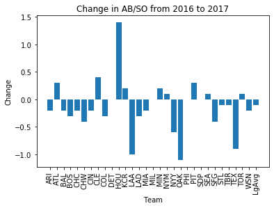

```python
difference = ratios2017['AB/SO'].subtract(ratios2016['AB/SO'])
plt.bar(ratios2017['Tm'], difference, align='center')
plt.xticks(rotation=90)
plt.ylabel('Change')
plt.xlabel('Team')
plt.title('Change in AB/SO from 2016 to 2017')
plt.show()
```

This plot reveals that the Houston Astros had a vastly greater improvement in AB/SO compared to every other team. Their AB/SO went up by 1.4 compared to the leage average which is actually negative. The second greatest improvement was only 0.4. Next we'll look at some pitch data from the 2017 season.

### 3.4

```python
display(pitches2017)
```

|  | Tm | Str% | L/Str | S/Str | F/Str | I/Str | AS/Str | I/Bll | AS/Pit | Con | ... | 20s | 31% | 31c | 31s | L/SO | S/SO | L/SO% | PAu | Pitu | Stru |
| --- | --- | --- | --- | --- | --- | --- | --- | --- | --- | --- | --- | --- | --- | --- | --- | --- | --- | --- | --- | --- | --- |
| 0 | ARI | 62.9% | 28.1% | 18.5% | 26.6% | 26.8% | 71.9% | 0.0% | 45.2% | 74.3% | ... | 299 | 9.2% | 574 | 308 | 369 | 1084 | 25.3% | 0 | 0 | 0 |
| 1 | ATL | 64.7% | 23.0% | 17.6% | 29.9% | 29.5% | 77.0% | 0.0% | 49.8% | 77.2% | ... | 341 | 8.2% | 508 | 293 | 238 | 938 | 20.1% | 0 | 0 | 0 |
| 2 | BAL | 64.6% | 25.2% | 19.6% | 27.3% | 28.0% | 74.8% | 0.0% | 48.3% | 73.8% | ... | 379 | 7.5% | 463 | 301 | 322 | 1089 | 22.8% | 0 | 0 | 0 |
| 3 | BOS | 62.7% | 30.2% | 15.3% | 26.1% | 28.4% | 69.8% | 0.0% | 43.8% | 78.1% | ... | 334 | 9.0% | 570 | 290 | 283 | 940 | 23.1% | 0 | 0 | 0 |
| 4 | CHC | 63.1% | 25.3% | 19.3% | 28.5% | 27.0% | 74.7% | 0.0% | 47.2% | 74.2% | ... | 366 | 8.8% | 556 | 297 | 321 | 1076 | 22.9% | 0 | 0 | 0 |
| 5 | CHW | 64.9% | 24.5% | 19.8% | 28.1% | 27.7% | 75.5% | 0.0% | 49.0% | 73.8% | ... | 352 | 7.2% | 438 | 268 | 280 | 1113 | 20.0% | 0 | 0 | 0 |
| 6 | CIN | 63.2% | 26.5% | 16.6% | 29.0% | 27.9% | 73.5% | 0.0% | 46.5% | 77.4% | ... | 354 | 8.9% | 556 | 302 | 343 | 976 | 25.8% | 0 | 0 | 0 |
| 7 | CLE | 61.6% | 27.1% | 15.6% | 28.4% | 28.9% | 72.9% | 0.0% | 44.9% | 78.7% | ... | 402 | 10.7% | 667 | 409 | 287 | 865 | 24.9% | 0 | 0 | 0 |
| 8 | COL | 63.9% | 26.0% | 18.4% | 28.1% | 27.5% | 74.0% | 0.0% | 47.3% | 75.1% | ... | 420 | 8.1% | 501 | 272 | 293 | 1111 | 20.8% | 0 | 0 | 0 |
| 9 | DET | 63.9% | 26.1% | 17.6% | 28.6% | 27.7% | 73.9% | 0.0% | 47.2% | 76.2% | ... | 376 | 8.9% | 546 | 314 | 276 | 1036 | 21.0% | 0 | 0 | 0 |
| 10 | HOU | 62.5% | 27.5% | 14.8% | 26.8% | 30.9% | 72.5% | 0.0% | 45.3% | 79.5% | ... | 404 | 9.6% | 603 | 353 | 254 | 833 | 23.4% | 0 | 0 | 0 |
| 11 | KCR | 65.0% | 22.0% | 17.8% | 30.5% | 29.7% | 78.0% | 0.0% | 50.7% | 77.1% | ... | 362 | 7.0% | 425 | 282 | 226 | 940 | 19.4% | 0 | 0 | 0 |
| 12 | LAA | 62.9% | 27.3% | 17.1% | 26.6% | 29.0% | 72.7% | 0.0% | 45.7% | 76.4% | ... | 366 | 8.8% | 534 | 292 | 259 | 938 | 21.6% | 0 | 0 | 0 |
| 13 | LAD | 61.3% | 28.4% | 17.6% | 26.7% | 27.3% | 71.6% | 0.0% | 43.9% | 75.4% | ... | 411 | 10.3% | 641 | 357 | 371 | 1004 | 26.9% | 0 | 0 | 0 |
| 14 | MIA | 64.1% | 27.1% | 16.5% | 27.8% | 28.6% | 72.9% | 0.0% | 46.7% | 77.4% | ... | 350 | 8.7% | 542 | 312 | 276 | 996 | 21.5% | 0 | 0 | 0 |
| 15 | MIL | 63.7% | 26.3% | 20.4% | 27.8% | 25.6% | 73.7% | 0.0% | 46.9% | 72.4% | ... | 354 | 8.7% | 536 | 308 | 398 | 1168 | 25.3% | 0 | 0 | 0 |
| 16 | MIN | 62.5% | 28.2% | 17.2% | 27.1% | 27.4% | 71.8% | 0.0% | 44.8% | 76.0% | ... | 348 | 10.1% | 631 | 332 | 328 | 1013 | 24.4% | 0 | 0 | 0 |
| 17 | NYM | 63.6% | 27.1% | 17.0% | 28.0% | 28.0% | 72.9% | 0.0% | 46.4% | 76.7% | ... | 365 | 8.7% | 537 | 302 | 290 | 997 | 22.5% | 0 | 0 | 0 |
| 18 | NYY | 61.8% | 26.8% | 18.8% | 27.1% | 27.3% | 73.2% | 0.0% | 45.3% | 74.3% | ... | 404 | 10.3% | 653 | 355 | 312 | 1074 | 22.5% | 0 | 1 | 0 |
| 19 | OAK | 62.5% | 26.1% | 19.6% | 28.1% | 26.2% | 73.9% | 0.0% | 46.2% | 73.5% | ... | 377 | 9.0% | 550 | 327 | 328 | 1163 | 22.0% | 0 | 0 | 0 |
| 20 | PHI | 64.0% | 26.0% | 18.7% | 28.3% | 27.0% | 74.0% | 0.0% | 47.3% | 74.7% | ... | 395 | 8.5% | 524 | 308 | 333 | 1081 | 23.5% | 0 | 0 | 0 |
| 21 | PIT | 63.3% | 27.0% | 16.2% | 28.7% | 28.2% | 73.0% | 0.0% | 46.2% | 77.8% | ... | 344 | 9.1% | 560 | 346 | 281 | 926 | 23.2% | 0 | 0 | 0 |
| 22 | SDP | 64.5% | 26.2% | 19.5% | 27.5% | 26.9% | 73.8% | 0.0% | 47.6% | 73.6% | ... | 331 | 7.8% | 467 | 273 | 383 | 1112 | 25.6% | 0 | 0 | 0 |
| 23 | SEA | 63.0% | 27.3% | 16.7% | 27.3% | 28.7% | 72.7% | 0.0% | 45.8% | 77.0% | ... | 399 | 8.5% | 526 | 310 | 322 | 944 | 25.4% | 0 | 0 | 0 |
| 24 | SFG | 63.5% | 25.1% | 17.0% | 28.1% | 29.8% | 74.9% | 0.0% | 47.6% | 77.3% | ... | 335 | 7.6% | 469 | 282 | 290 | 913 | 24.1% | 0 | 0 | 0 |
| 25 | STL | 62.4% | 27.1% | 17.3% | 28.1% | 27.4% | 72.9% | 0.0% | 45.5% | 76.3% | ... | 364 | 9.2% | 573 | 280 | 327 | 1016 | 24.3% | 0 | 0 | 0 |
| 26 | TBR | 63.4% | 22.9% | 21.8% | 29.0% | 26.3% | 77.1% | 0.0% | 48.9% | 71.7% | ... | 407 | 7.9% | 490 | 273 | 349 | 1186 | 22.7% | 0 | 0 | 0 |
| 27 | TEX | 62.9% | 26.2% | 20.0% | 27.6% | 26.1% | 73.8% | 0.0% | 46.4% | 72.8% | ... | 369 | 8.9% | 549 | 338 | 333 | 1160 | 22.3% | 0 | 0 | 0 |
| 28 | TOR | 62.8% | 27.9% | 17.1% | 27.4% | 27.7% | 72.1% | 0.0% | 45.3% | 76.4% | ... | 361 | 9.4% | 579 | 319 | 321 | 1005 | 24.2% | 0 | 1 | 0 |
| 29 | WSN | 62.9% | 27.1% | 17.0% | 27.9% | 28.0% | 72.9% | 0.0% | 45.8% | 76.7% | ... | 375 | 8.7% | 543 | 306 | 317 | 1008 | 23.9% | 0 | 0 | 0 |
| 30 | LgAvg | 63.2% | 26.4% | 17.9% | 27.9% | 27.8% | 73.6% | 0.0% | 46.6% | 75.7% | ... | 368 | 8.8% | 544 | 310 | 310 | 1024 | 23.2% | 0 | 0 | 0 |

31 rows × 26 columns

In this table, there are four stats that I'm interested in. First is S/Str. S/Str is the number of strikes swung at without contact divided by the total number of strikes.  
Next is I/Str. I/Str is balls put into play divided by total strikes. Third is Con which is the percentage of strikes that they made contact with. The last is S/SO which is the number of strikeouts swinging. I'll make a bar plot to help visualize S/Str.

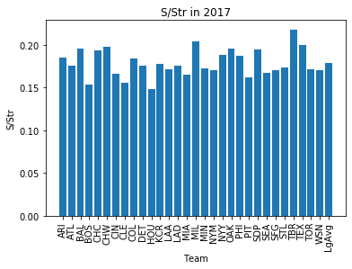

```python
#Function to convert strings that are percentages into floats.
def p2f(x):
    return float(x.strip('%'))/100

s_str_list = []
for i in pitches2017['S/Str']:
    s_str_list.append(p2f(i))
#Plotting S/Str
plt.bar(pitches2017['Tm'], s_str_list, align='center')
plt.xticks(rotation=90)
plt.ylabel('S/Str')
plt.xlabel('Team')
plt.title('S/Str in 2017')
plt.show()
```

Looking at this plot and table, we see that the Astros led the MLB in all four of these stats. First, they had the lowest S/Str. In baseball, batters are most likely to swing and miss when they are expecting a breaking ball and it's actually a fastball or vice versa. In other words, when they guess the next pitch wrong. If a batter knew what pitch was coming and didn't have to guess, their S/Str should be lower, as it is for the Astros.  
Next, the Astros had the highest I/Str. Again, if a batter didn't have to guess which pitch is coming, it would be easier to put balls into play.  
Similarly, the Astros led the MLB in Con.  
Finally, the Astros had the least S/SO. This stat is correlated to the one looked at in 3.3.

## 4. Machine Learning

Next, we'll use a linear regression model to try and predict wins based on the previous year's wins. First, we'll create a new DataFrame for the Astros with three columns: year, wins, and previous year's wins. We'll use the data that we retrieved in part 3.1.

```python
#Dropping 1998 because it won't have data for the previous year's wins
year_list = year_list.drop(year_list.index[21])

previous_wins = astros_wins.iloc[1:]
previous_wins.index = np.arange(21)
#Dropping 1998 again
astros_wins = astros_wins.drop(astros_wins.index[21])

frame = { 'Year': year_list, 'Wins': astros_wins, 'Previous Wins': previous_wins }
astros_data = pd.DataFrame(frame)
display(astros_data)
```

|  | Year | Wins | Previous Wins |
| --- | --- | --- | --- |
| 0 | 2019 | 107.0 | 103.0 |
| 1 | 2018 | 103.0 | 101.0 |
| 2 | 2017 | 101.0 | 84.0 |
| 3 | 2016 | 84.0 | 86.0 |
| 4 | 2015 | 86.0 | 70.0 |
| 5 | 2014 | 70.0 | 51.0 |
| 6 | 2013 | 51.0 | 55.0 |
| 7 | 2012 | 55.0 | 56.0 |
| 8 | 2011 | 56.0 | 76.0 |
| 9 | 2010 | 76.0 | 74.0 |
| 10 | 2009 | 74.0 | 86.0 |
| 11 | 2008 | 86.0 | 73.0 |
| 12 | 2007 | 73.0 | 82.0 |
| 13 | 2006 | 82.0 | 89.0 |
| 14 | 2005 | 89.0 | 92.0 |
| 15 | 2004 | 92.0 | 87.0 |
| 16 | 2003 | 87.0 | 84.0 |
| 17 | 2002 | 84.0 | 93.0 |
| 18 | 2001 | 93.0 | 72.0 |
| 19 | 2000 | 72.0 | 97.0 |
| 20 | 1999 | 97.0 | 102.0 |

Now I'll split the data into a training set and a testing set and create a linear regression.

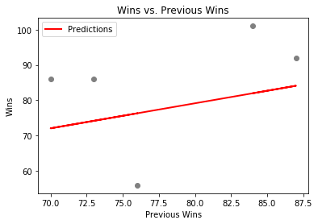

```python
# Separate into x = the independent variable, and y = the dependent variable
x = astros_data['Previous Wins'].values.reshape(-1,1)
y = astros_data['Wins'].values.reshape(-1,1)

# Separate into train and test datasets
x_train, x_test, y_train, y_test = model_selection.train_test_split(x, y, test_size=0.2)

regressor = LinearRegression()
regressor.fit(x_train, y_train)
y_pred = regressor.predict(x_test)

#Plotting the test data compared to the predicted win counts.
plt.scatter(x_test, y_test,  color='gray')
plt.plot(x_test, y_pred, color='red', linewidth=2, label='Predictions')
plt.ylabel('Wins')
plt.xlabel('Previous Wins')
plt.legend()
plt.title('Wins vs. Previous Wins')
plt.show()
```

As we can see, this isn't a useful model to use, as the predictions can be over 10 wins away from the actual result. This is likely for a couple of reasons. For one, we only have a small dataset with only 20 years. More importantly though, we only have one independent variable, and it is not very connected to the dependent variable. You can't accurately predict how many wins a team will achieve solely based on how many wins they achieved the previous year. Teams change every year so this model is useless for us.

## 5. Conclusion

After going through the data pipeline and analyzing the statistics, there is not much, if anything at all, to hint that the Astros were cheating. While the data analysis from 3.2, 3.3, and 3.4 make it appear that they may of had an advantage that resulted in them being the best team, there could be other reasons for this improvement other than cheating. For example, each year rosters change and they get rid of poor performing players and get new, hopefully better players. Players also sometimes just improve as a result of practice and experience.  
It's also possible that there is some bias in the data analysis, because it is common that when you have an end result in mind (that the Astros cheated), you look for the data that confirms that result and ignore data that points against it. Overall, statistics can't be used to prove or disprove the allegations. It's possible that they cheated only in important game situations, meaning that their overall statistics wouldn't change much. MLB's on-going investigation will have to be more focused on the video evidence and other sources rather than any statistics.